# Lab 4

Author

Vicki

```r
library(data.table)
library(leaflet)
library(tidyverse)
library(ggplot2)
```

# 1

```r
if (!file.exists("met_all.gz"))
  download.file(
    url = "https://raw.githubusercontent.com/USCbiostats/data-science-data/master/02_met/met_all.gz",
    destfile = "met_all.gz",
    method   = "libcurl",
    timeout  = 60
    )
met <- data.table::fread("met_all.gz")
```

# 2

```r
met <- met[temp > -17] [elev == 9999.0, elev := NA]

met[, week := week(as.Date(paste(year, month, day, sep = "-")))]

met <- met[week == min(week, na.rm = TRUE)]

met_avg <- met[,.(temp=mean(temp,na.rm=TRUE), rh=mean(rh,na.rm=TRUE),
                  wind.sp=mean(wind.sp,na.rm=TRUE),
                vis.dist=mean(vis.dist,na.rm=TRUE),
                dew.point=mean(dew.point, na.rm=TRUE),
                lat=mean(lat), lon=mean(lon),
                elev=mean(elev,na.rm=TRUE)), by="USAFID"]

met_avg$region <- ifelse(met_avg$lon > -98 & met_avg$lat >39.71, "north east",
                         ifelse(met_avg$lon > -98 &
                                  met_avg$lat < 39.71, "south east",
                                ifelse(met_avg$lon < -98 & met_avg$lat >39.71,
                                       "north west", "south west")))

met_avg$elev_cat <- ifelse(met_avg$elev> 252, "high", "low")
```

# 3

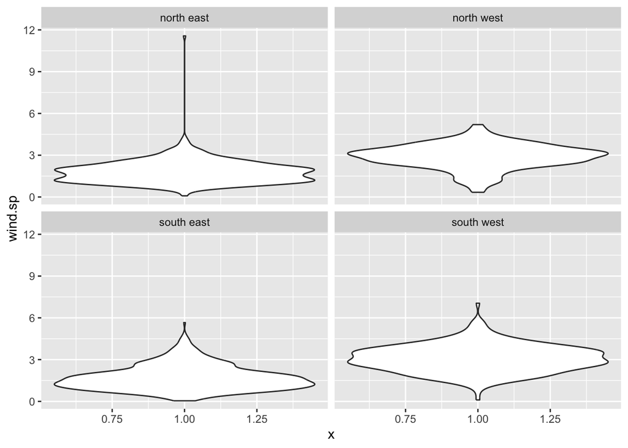

```r
met_avg %>%
  filter(!(wind.sp %in% NA)) %>%
ggplot()+
  geom_violin(mapping = aes(y=wind.sp, x=1)) +
  facet_wrap(~region, nrow=2)
```

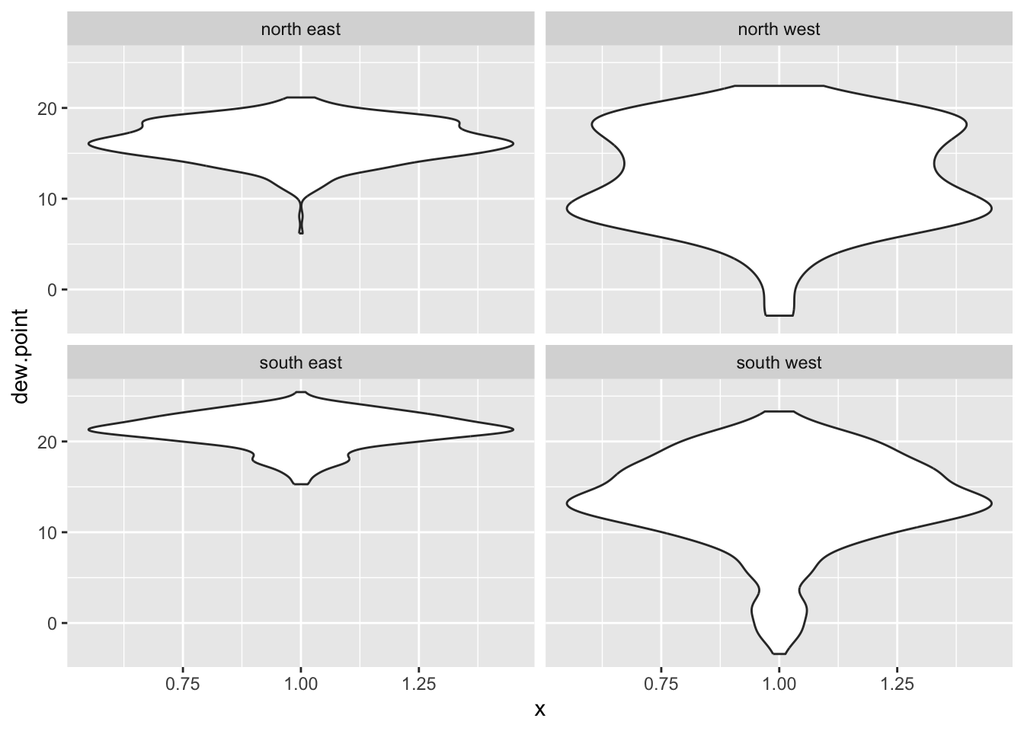

```r
met_avg %>%
  filter(!(dew.point %in% NA)) %>%
ggplot()+
  geom_violin(mapping = aes(y=dew.point, x=1)) +
  facet_wrap(~region, nrow=2)
```

**The violin plot for wind speed varies by region where wind speeds for the northeast and southeast tend to be lower in comparison to the southwest and northwest regions, based on the widths. It is interesting to note that the violin plot for the wind speed in the north east region most likely has a lot of outliers given the long tail. For dew points, the violin plot shows relatively consistent dew points for the north east and south east regions. However, for the southwest and the northwest regions, the distribution of dew points vary from high to low, especially for the north west region which shows a varied density by observing its width.**